# #TidyTuesday -> #TidyThursday

Andrea + Sina  
June 7 2018

### Why TidyTuesday?

> [#TidyTuesday](https://twitter.com/hashtag/TidyTuesday?src=hash&ref_src=twsrc%5Etfw) is a great initiative for [#SoDS18](https://twitter.com/hashtag/SoDS18?src=hash&ref_src=twsrc%5Etfw) learners looking for practice projects to check out! https://t.co/xQSnpq5j8x

> — Data Science Renee (@BecomingDataSci) [June 6, 2018](https://twitter.com/BecomingDataSci/status/1004395020831608832?ref_src=twsrc%5Etfw)

### Levels of understanding

There are four stages of understanding of the concept of TidyTuesday:

1. Ignoring it.
2. Partially ignoring it, but slowly getting why it's on Tuesday.
3. Finally getting it and being like 😮.
4. Participate.

The good news is, that transitioning from 1 - 4 is super easy by design!

### R4DS community

R4DS = R for Data Science Online Learning Community

Goal: *creating a supportive and responsive online space for learners and mentors to gather and work through the R for Data Science text*

- R4DS community: http://www.rfordatasci.com/ initiated by [Jesse Maegan](https://www.jessemaegan.com/) ([@kierisi](https://twitter.com/kierisi) on twitter)
- R4DS is a book: http://r4ds.had.co.nz/ (free online book)
- R4DS community works through [Blog](http://www.rfordatasci.com/blog/) + Twitter + Slack
- ➡️ [TidyTuesday](https://github.com/rfordatascience/tidytuesday) is part of this initiative

### Tidyverse ecosystem

```r
library(tidyverse)
## Base functions have analogous functions in the tidyverse.
```

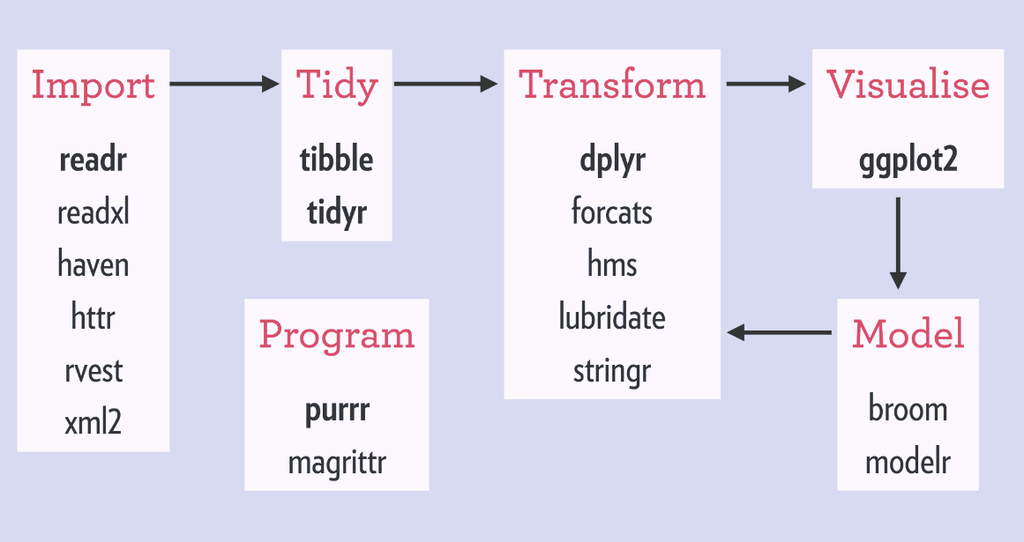

### What is #TidyTuesday?

*A weekly data wrangling & visualisation project*

➡️ [Github repo](https://github.com/rfordatascience/tidytuesday)

➡️ [Details](https://thomasmock.netlify.com/post/tidytuesday-a-weekly-social-data-project-in-r/)

- Founded by [Jesse Maegan](https://www.jessemaegan.com/) and [Thomas Mock](http://thomasmock.netlify.com/)
- Started in April 2018
- addresses the need of learning the tidyverse ecosystem by separating the technical and the interpretation part of DS.
- Tamed, bot not *tidy* datasets along with some kind of template (articles)

### How does #TidyTuesday work?

- Data is released on **Monday**
- Wrangle & visualise on **Tuesday**
- publish results + code on twitter (#TidyTuesday)

### How to participate in TidyTuesday

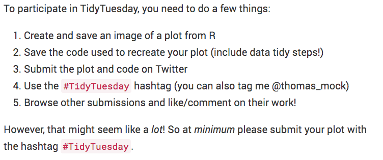

### Datasets: the gold mine!

A variety of types of data!

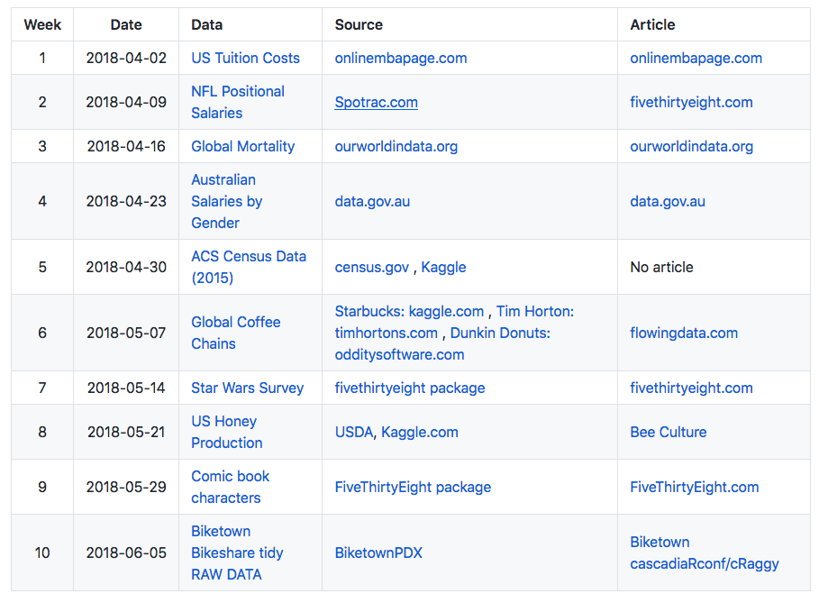

### The principle: Data + Publication

[figure not shown]

+

[figure not shown]

=

[figure not shown]

### What are the possibilities?

- **Playing** with data: data wrangling (tidying) + visualisation. Practicing the core skillset that helps us to do DS.
- This combination of data + published figures allows you to explore tidyverse on **different levels**: reproduce something or create something new
- having a **community**: learn from others
- addresses the lack of **new data at work** (without having to think about implications).
- It is like homework that you won't get checked on 😎.

### Example of creating something new!

> My [#TidyTuesday](https://twitter.com/hashtag/TidyTuesday?src=hash&ref_src=twsrc%5Etfw) week 9 submission: top 10 hair colors for comic book characters. I excluded NAs, bald and no hair, and I manually set the plot colors to match the categorical variables :) [pic.twitter.com/h36n8xLveK](https://t.co/h36n8xLveK)

> — Nathania Johnson (@nlj) [May 30, 2018](https://twitter.com/nlj/status/1001920513244057600?ref_src=twsrc%5Etfw)

### Activity around #TidyTuesday

> Number of [#TidyTuesday](https://twitter.com/hashtag/TidyTuesday?src=hash&ref_src=twsrc%5Etfw) tweets has held steady after initial burst of activity. I'm hoping it lasts for a while! [pic.twitter.com/dx7sbsrZhh](https://t.co/dx7sbsrZhh)

> — Mike Kearney📊 (@kearneymw) [June 5, 2018](https://twitter.com/kearneymw/status/1004107694389780486?ref_src=twsrc%5Etfw)

### Currently: Week 10

> Welcome to week 10 of [#tidytuesday](https://twitter.com/hashtag/tidytuesday?src=hash&ref_src=twsrc%5Etfw)!  
> In collaboration with [@cascadiarconf](https://twitter.com/cascadiarconf?ref_src=twsrc%5Etfw) and [@smithjd](https://twitter.com/smithjd?ref_src=twsrc%5Etfw) let's explore [#biketown](https://twitter.com/hashtag/biketown?src=hash&ref_src=twsrc%5Etfw) data!  
> Data: https://t.co/J46z0iFGQp  
> Source: https://t.co/kLmoBtPOLy  
> Source was made in [#tableau](https://twitter.com/hashtag/tableau?src=hash&ref_src=twsrc%5Etfw) but let's see what open source [#rstats](https://twitter.com/hashtag/rstats?src=hash&ref_src=twsrc%5Etfw) can do![#dataviz](https://twitter.com/hashtag/dataviz?src=hash&ref_src=twsrc%5Etfw) [#tidyverse](https://twitter.com/hashtag/tidyverse?src=hash&ref_src=twsrc%5Etfw) [pic.twitter.com/D1YjgwIz9a](https://t.co/D1YjgwIz9a)

> — R4DS online learning community (@R4DScommunity) [June 4, 2018](https://twitter.com/R4DScommunity/status/1003677238120910848?ref_src=twsrc%5Etfw)

### Week 10

## Data

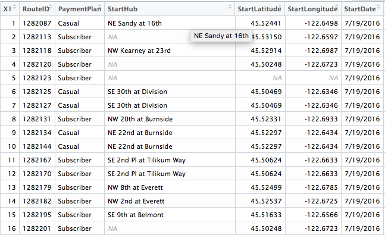

### Week 10

## Article

[figure not shown]

### Week 10

## Work by community

> It's Tuesday again! For this week's [#TidyTuesday](https://twitter.com/hashtag/TidyTuesday?src=hash&ref_src=twsrc%5Etfw) Biketown dataset, I looked at round trips (start hub = end hub) plotted on a map, and boxplots of distance by trip type. Code can be found here: https://t.co/JVob01BLv8. [#rstats](https://twitter.com/hashtag/rstats?src=hash&ref_src=twsrc%5Etfw) [#r4ds](https://twitter.com/hashtag/r4ds?src=hash&ref_src=twsrc%5Etfw) [pic.twitter.com/Vn1ohVmj57](https://t.co/Vn1ohVmj57)

> — veerlevanson (@veerlevanson) [June 5, 2018](https://twitter.com/veerlevanson/status/1004113584857780224?ref_src=twsrc%5Etfw)

### Hands-on

[output not shown]

### Hands-on

## R-Code

Download R-script (that downloads data) [here](https://rawgit.com/rladies/meetup-presentations_lausanne/master/20180607_thundeR/3_tidytuesday/get-started-tidytuesday.R).

```r
library(tidyverse)
```

### Hands-on

## Week 9: Comic characters

```r
## from https://raw.githubusercontent.com/rfordatascience/tidytuesday/master/data/
##
dat.comic <- read_csv("tidytuesday-data/week9_comic_characters.csv")
```

### Hands-on

## Week 10: Biketown Bikeshare

```r
## from https://github.com/rfordatascience/tidytuesday/blob/master/data/week10_biketown.zip
dat.bike <- read_csv("tidytuesday-data/week10_biketown.csv")
```